# Pima Indian Diabetes Data Analysis in R

### Probit Model

```
##
## Call:
## glm(formula = Outcome ~ ., family = binomial(link = "probit"),
##     data = train)
##
## Deviance Residuals:
##     Min       1Q   Median       3Q      Max
## -2.8225  -0.7360  -0.3650   0.6946   2.4835
##
## Coefficients:
##                     Estimate Std. Error z value Pr(>|z|)
## (Intercept)       -5.7473975  0.5989678  -9.596  < 2e-16 ***
## Pregnancies        0.0615169  0.0244143   2.520 0.011745 *
## Glucose            0.0238748  0.0032424   7.363 1.79e-13 ***
## BloodPressure     -0.0030868  0.0067005  -0.461 0.645027
## SkinThickness      0.0090945  0.0110320   0.824 0.409726
## Insulin           -0.0007149  0.0011852  -0.603 0.546391
## BMI                0.0559867  0.0164841   3.396 0.000683 ***
## Diab.Pedigree.Fun  0.6039258  0.2233500   2.704 0.006852 **
## Age                0.0020865  0.0075246   0.277 0.781555
## ---
## Signif. codes:  0 '***' 0.001 '**' 0.01 '*' 0.05 '.' 0.1 ' ' 1
##
## (Dispersion parameter for binomial family taken to be 1)
##
##     Null deviance: 650.62  on 509  degrees of freedom
## Residual deviance: 462.84  on 501  degrees of freedom
## AIC: 480.84
##
## Number of Fisher Scoring iterations: 5
```

```
## Confusion Matrix and Statistics
##
##           Reference
## Prediction   0   1
##          0 127  31
##          1  17  44
##
##                Accuracy : 0.7808
##                  95% CI : (0.7201, 0.8338)
##     No Information Rate : 0.6575
##     P-Value [Acc > NIR] : 4.722e-05
##
##                   Kappa : 0.4905
##
##  Mcnemar's Test P-Value : 0.0606
##
##             Sensitivity : 0.8819
##             Specificity : 0.5867
##          Pos Pred Value : 0.8038
##          Neg Pred Value : 0.7213
##              Prevalence : 0.6575
##          Detection Rate : 0.5799
##    Detection Prevalence : 0.7215
##       Balanced Accuracy : 0.7343
##
##        'Positive' Class : 0
##
```

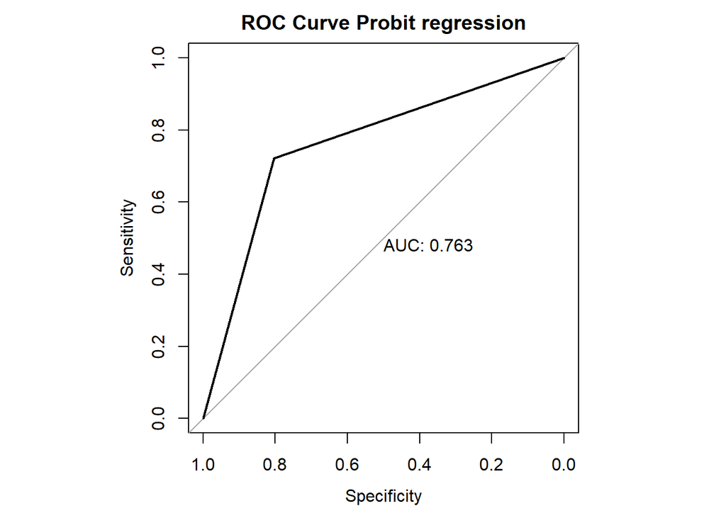

```
##
## Call:
## roc.default(response = factor(round(predict(probit_model, newdata = test,     type = "response"), 0)), predictor = test$Outcome, plot = TRUE,     print.auc = TRUE, main = "ROC Curve Probit regression")
##
## Data: test$Outcome in 158 controls (factor(round(predict(probit_model, newdata = test, type = "response"), 0)) 0) < 61 cases (factor(round(predict(probit_model, newdata = test, type = "response"), 0)) 1).
## Area under the curve: 0.7626
```

$\qquad$ Interestingly, according to the logit and probit models, the variables insulin, blood pressure, fold thickness and age are not significant. The final versions of the models with significant variables will be selected using backward stepwise approach.

### Logit Model with significant variables

```
##
## Call:
## glm(formula = Outcome ~ Pregnancies + Glucose + BMI + Diab.Pedigree.Fun,
##     family = "binomial", data = train)
##
## Deviance Residuals:
##     Min       1Q   Median       3Q      Max
## -2.7305  -0.7182  -0.3957   0.6669   2.4697
##
## Coefficients:
##                    Estimate Std. Error z value Pr(>|z|)
## (Intercept)       -9.777277   0.918275 -10.647  < 2e-16 ***
## Pregnancies        0.112604   0.034449   3.269  0.00108 **
## Glucose            0.038435   0.004405   8.725  < 2e-16 ***
## BMI                0.102212   0.019820   5.157 2.51e-07 ***
## Diab.Pedigree.Fun  1.096031   0.382415   2.866  0.00416 **
## ---
## Signif. codes:  0 '***' 0.001 '**' 0.01 '*' 0.05 '.' 0.1 ' ' 1
##
## (Dispersion parameter for binomial family taken to be 1)
##
##     Null deviance: 650.62  on 509  degrees of freedom
## Residual deviance: 465.49  on 505  degrees of freedom
## AIC: 475.49
##
## Number of Fisher Scoring iterations: 5
```

```
## Confusion Matrix and Statistics
##
##           Reference
## Prediction   0   1
##          0 128  30
##          1  16  45
##
##                Accuracy : 0.79
##                  95% CI : (0.73, 0.8419)
##     No Information Rate : 0.6575
##     P-Value [Acc > NIR] : 1.25e-05
##
##                   Kappa : 0.5118
##
##  Mcnemar's Test P-Value : 0.05527
##
##             Sensitivity : 0.8889
##             Specificity : 0.6000
##          Pos Pred Value : 0.8101
##          Neg Pred Value : 0.7377
##              Prevalence : 0.6575
##          Detection Rate : 0.5845
##    Detection Prevalence : 0.7215
##       Balanced Accuracy : 0.7444
##
##        'Positive' Class : 0
##
```

[figure not shown]

[output not shown]

### Probit Model with significant variables

```
##
## Call:
## glm(formula = Outcome ~ Pregnancies + Glucose + BMI + Diab.Pedigree.Fun,
##     family = binomial(link = "probit"), data = train)
##
## Deviance Residuals:
##     Min       1Q   Median       3Q      Max
## -2.8798  -0.7307  -0.3781   0.6811   2.5520
##
## Coefficients:
##                    Estimate Std. Error z value Pr(>|z|)
## (Intercept)       -5.783434   0.494321 -11.700  < 2e-16 ***
## Pregnancies        0.066295   0.019813   3.346  0.00082 ***
## Glucose            0.022621   0.002447   9.243  < 2e-16 ***
## BMI                0.061302   0.011278   5.435 5.47e-08 ***
## Diab.Pedigree.Fun  0.611841   0.222657   2.748  0.00600 **
## ---
## Signif. codes:  0 '***' 0.001 '**' 0.01 '*' 0.05 '.' 0.1 ' ' 1
##
## (Dispersion parameter for binomial family taken to be 1)
##
##     Null deviance: 650.62  on 509  degrees of freedom
## Residual deviance: 464.06  on 505  degrees of freedom
## AIC: 474.06
##
## Number of Fisher Scoring iterations: 5
```

```
## Confusion Matrix and Statistics
##
##           Reference
## Prediction   0   1
##          0 128  30
##          1  16  45
##
##                Accuracy : 0.79
##                  95% CI : (0.73, 0.8419)
##     No Information Rate : 0.6575
##     P-Value [Acc > NIR] : 1.25e-05
##
##                   Kappa : 0.5118
##
##  Mcnemar's Test P-Value : 0.05527
##
##             Sensitivity : 0.8889
##             Specificity : 0.6000
##          Pos Pred Value : 0.8101
##          Neg Pred Value : 0.7377
##              Prevalence : 0.6575
##          Detection Rate : 0.5845
##    Detection Prevalence : 0.7215
##       Balanced Accuracy : 0.7444
##
##        'Positive' Class : 0
##
```

[figure not shown]

[output not shown]

$\qquad$ All model parameters are positive, it was to be expected, as there is a positive correlation between them and the result.

$X = -5.783 + 3 \cdot 0.066 + 200 \cdot 0.023 + 30 \cdot 0.061 + 0,8 \cdot 0.612=1,335$

$\frac{1}{1 + e^{-X}}=\frac{1}{1 +e^{-1,335}}=0.791$

### Random Forest

$\qquad$ Random Forest is an extension of Bagging. The number of variables for the construction of each tree is additionally randomly selected, usually their number equals to a square root of the number of all variables. It avoids a situation in which only the most differentiating variables are used to build trees. After creating a forest, it is possible to check how differentiating individual variables are.

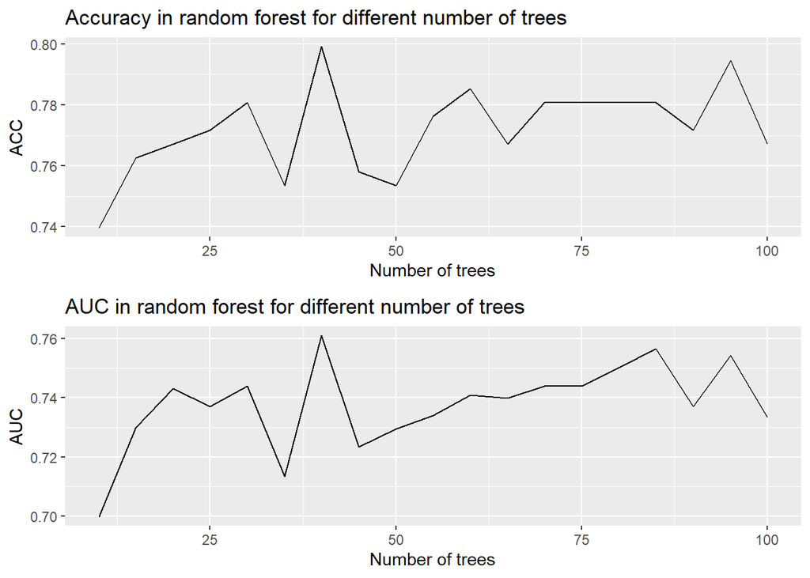

### Differentiating variables in a random forest

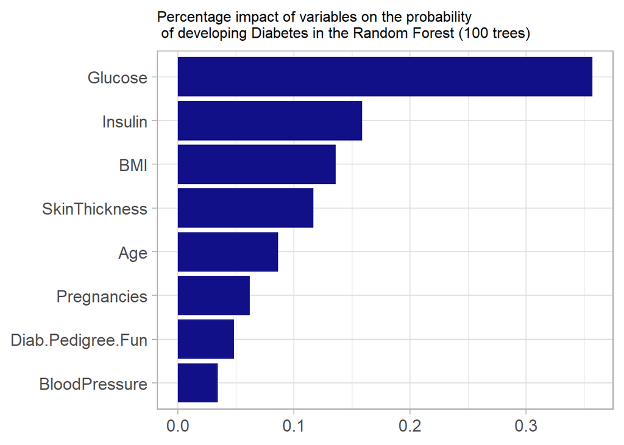

## Local-diagnostics Plots

$\qquad$ For a random forest with a hundred trees, for 3 selected characteristic observations, I will check how the change in the values of individual variables (ceteris paribus) will affect the probability of disease.

[output not shown]

### Daksha

| Pregnancies | Glucose | BloodPressure | SkinThickness | Insulin | BMI | Diab.Pedigree.Fun | Age | Outcome |
| --- | --- | --- | --- | --- | --- | --- | --- | --- |
| 8 | 188 | 78 | 40.4 | 314.9 | 47.9 | 0.137 | 43 | 1 |

```
## [1] 0.89
```

$\qquad$ Daksha is a 43-year-old woman who has been pregnant 8 times and has a fairly high level of glucose and insulin. According to the Random Forest, the probability of diabetes is 89% and she has actually been diagnosed with diabetes.

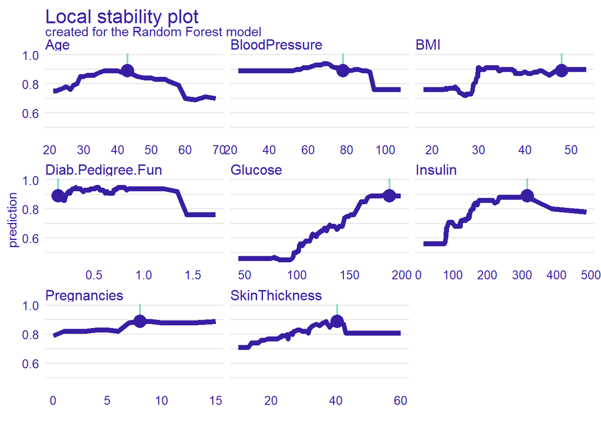

### Sailaja

|  | Pregnancies | Glucose | BloodPressure | SkinThickness | Insulin | BMI | Diab.Pedigree.Fun | Age | Outcome |
| --- | --- | --- | --- | --- | --- | --- | --- | --- | --- |
| 4 | 1 | 89 | 66 | 23 | 94 | 28.1 | 0.167 | 21 | 0 |

```
## [1] 0.01
```

$\qquad$ Sailaja is only 21 years old and has very low insulin, glucose and blood pressure values. The probability that such a person will have diabetes is only about 1% according to Random Forest.

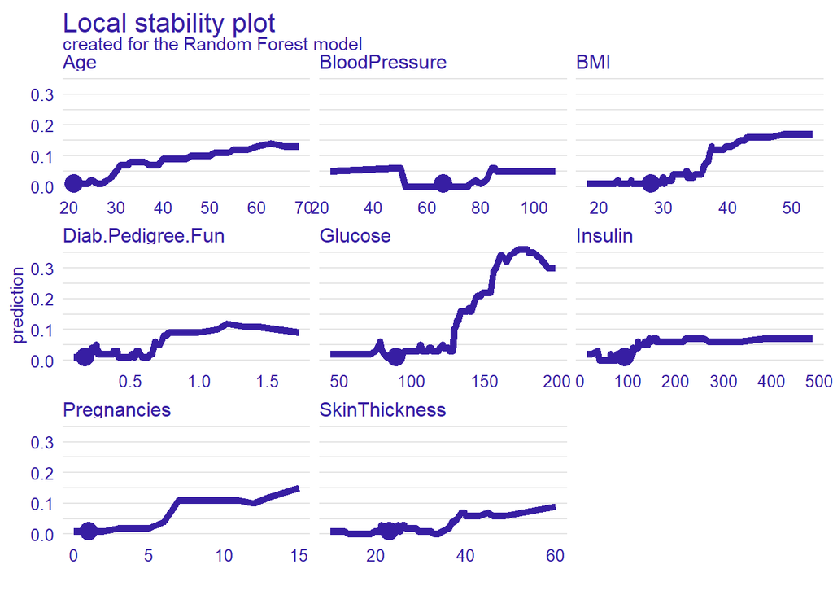

$\qquad$ In this case, it can be observed that if Sailaja’s glucose levels rose above about 160 units, the chance of diabetes would increase to 35% from the initial percentage. On the other hand, with large increases in other variables, but with low glucose levels, this probability increases to a maximum of 20%. .

### Krisha

| Pregnancies | Glucose | BloodPressure | SkinThickness | Insulin | BMI | Diab.Pedigree.Fun | Age | Outcome |
| --- | --- | --- | --- | --- | --- | --- | --- | --- |
| 2 | 100 | 66 | 20 | 90 | 32.9 | 0.867 | 28 | 1 |

```
## [1] 0.6
```

$\qquad$ Krisha has low blood glucose and insulin levels, but her DiabetesPedigreeFunction index is high, which means that her family has a history of diabetes and may have a genetic predisposition for it. Her body mass index is also above normal, values in the range 30.0 - 34.99 are classified as the 1st degree of obesity. According to a random forest with 100 trees, Krisha has a 60% chance of diabetes.

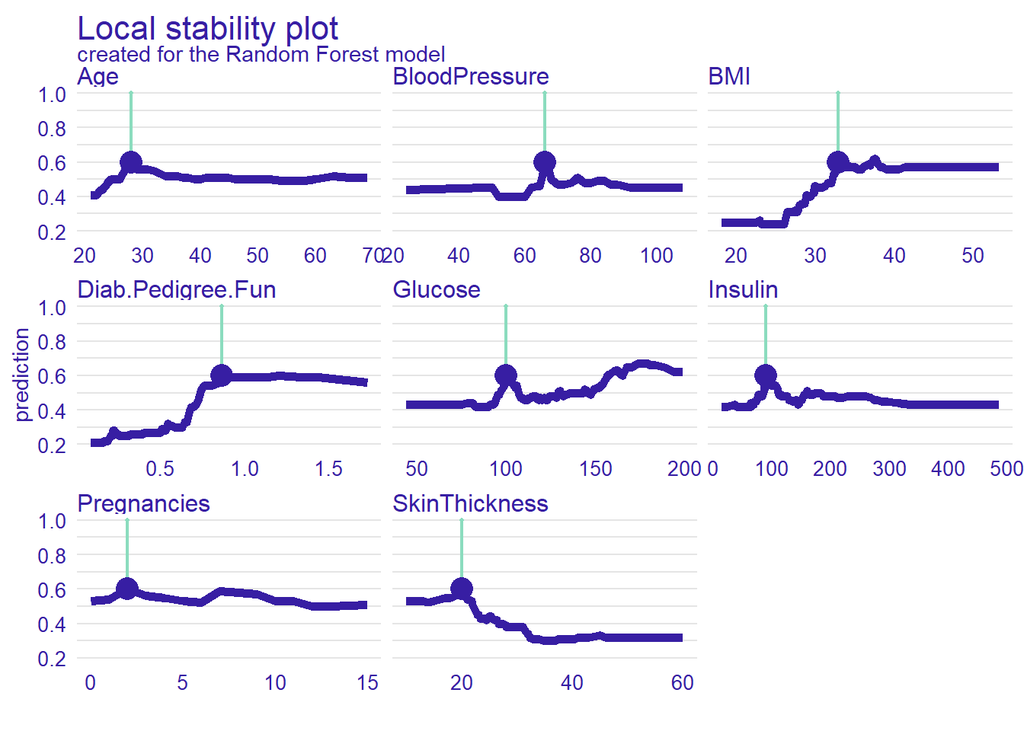

$\qquad$ The charts show a large influence of family history and BMI on the result. The variable she has influence on is the body mass index, if its value fell to normal (25 units), the probability of diabetes would decrease to 25%.

## Summary and Conclusions

[output not shown]

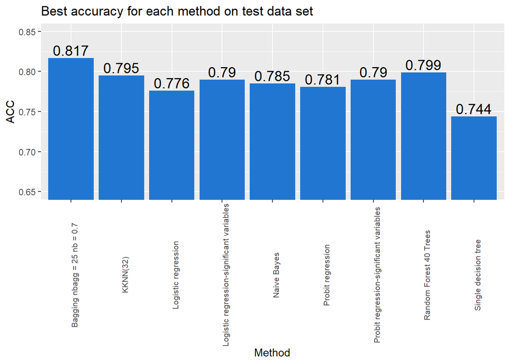

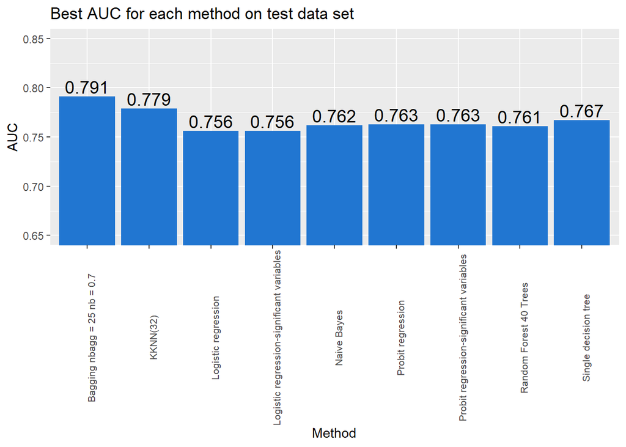

- The best accuracy and simultaneously AUC value were obtained for Bagging with 25 trees and 70% observations for a single tree creation.
- In Bagging, the manipulation of parameters significantly influenced the achieved accuracy, unlike, for example, in the Adult dataset, where a change in the number of trees or the nb parameter caused a change in accuracy by parts of a thousand.
- Overall, decision tree extensions that are Bagging and Random Forest did the best, followed by the Weighted Nearest Neighbor Method
- A single decision tree performed the worst in the test data set, but even the result of accuracy = 74.4% is not very weak.
- The insignificance of insulin level and age in probit and logit models turned out to be interesting, taking into account that in the random forest these variables turned out to be relatively strongly differentiating.
- An interesting relationship was observed in the KKNN algorithm. The selection of 32 neighbors turned out to be the most effective in the test set, which is quite a high parameter value for this algorithm.

$\qquad$ The obtained results can be considered as satisfactory. Due to the simultaneous manipulation of parameters, the Bagging achieves the highest accuracy. The study was conducted on data from a fairly specific group of people, but probably for a different set of data, equally good results would be obtained. If the new set also included men, the number of past pregnancies should be disregarded when predicting their diabetes. It would be justified to divide the new subset by sex also due to other norms of health parameters, such as glucose or BMI.